# Plotting Year ~ Dissimilarity Model

```r
library(ggplot2)
library(data.table)
library(lme4)
library(mgcv)
library(tidymv)
```

Load data and model

```r
#intercept_slope_varies <- readRDS("~/homogenization_analyses/intercept_slope_varies.rds")
distances_dissimilarities_allyears <- readRDS("/Users/zoekitchel/Documents/grad_school/Rutgers/Repositories/trawl_spatial_turnover_git/output/distance_decay/distances_dissimilarities_allyears.rds")
```

Prep distances dissimilarities

```r
#season_survey = factor
distances_dissimilarities_allyears[,season_survey := factor(season_survey)]

#add new variable for year in sequence per region
distances_dissimilarities_allyears[,first_year := min(year),.(season_survey)]
distances_dissimilarities_allyears[,last_year := max(year),.(season_survey)]

distances_dissimilarities_allyears[,year_in_seq := year-first_year+1]

distances_dissimilarities_allyears[,years_sampled := last_year-first_year+1]

survey_season_sampling_years <- unique(distances_dissimilarities_allyears[,.(season_survey, years_sampled)])

#list all survey units
season_survey.list <- unique(survey_season_sampling_years[,season_survey])
```

```r
palette_28 <- c("#5A5156","#F6222E","#FE00FA",
  "#16FF32","#3283FE","#FEAF16","#B00068",
  "#1CFFCE","#90AD1C","#2ED9FF","#DEA0FD",
  "#AA0DFE","#F8A19F","#325A9B","#C4451C",
  "#1C8356","#85660D","#B10DA1","#FBE426",
  "#1CBE4F","#FA0087","#FC1CBF","#F7E1A0",
  "#C075A6","#782AB6","#AAF400","#BDCDFF",
  "#822E1C")

color_link <- data.table(season_survey = season_survey,hex = palette_28)
```

[output not shown]

Let’s try to learn more about this model. Confint won’t run: confint(linear.mod.n, oldNames=FALSE) Computing profile confidence intervals … Error in zetafun(np, ns) : profiling detected new, lower deviance In addition: Warning message: In doTryCatch(return(expr), name, parentenv, handler) : restarting interrupted promise evaluation

Summary of model where we include every possible pairwise dissimilarity metric.

```r
summary(intercept_slope_varies) #
```

Plotting LMER with input of every possible pairing

```r
# see group coefficients
summary(intercept_slope_varies)
model_coefs <- coef(intercept_slope_varies)$season_survey

intercept_slope_varies_confint <- system.time(confint(intercept_slope_varies, oldNames = F))

model_coefs$season_survey <- rownames(model_coefs)

model_coefs <- data.table(model_coefs)

#merge with duration of survey
model_coefs_length <- model_coefs[survey_season_sampling_years, on = "season_survey"]

model_coefs_length[,years_sampled := as.numeric(years_sampled)][,Directional_Change := ifelse(year_in_seq > 0, "Differentiation","Homogenization")]

#min max distances_dissimilarities
min_bray <- min(distances_dissimilarities_allyears[,bray_curtis_dissimilarity_balanced], na.rm = T)
max_bray <- max(distances_dissimilarities_allyears[,bray_curtis_dissimilarity_balanced], na.rm = T)

#order table by coefficient
setkey(model_coefs_length, year_in_seq)


ggplot(data = model_coefs_length, aes(x = reorder(season_survey, year_in_seq) , y = year_in_seq, label = season_survey)) +
  geom_point(stat = 'identity', aes(size = years_sampled, color = Directional_Change)) +
  scale_size_binned(range = c(1,8), name = "Survey Period Length") +
  scale_color_discrete(name = "Directional Change") +
  geom_hline(yintercept = 0) +
  xlab("Season and Survey") +
  ylab("Coef BC Dissimilarity ~ Year") +
  coord_flip() +
  theme_classic()
```

Alternatively, what if instead of numbers of years sampled, we pull in SD of random effect coefficients from the model. 0.0031413 SD for all? Can’t get convint to work

```r
summary(mod1)$varcor

BC_Dissimilarity_Coef_errorbar <- ggplot(data = model_coefs_length, aes(x = reorder(season_survey, year_in_seq) , y = year_in_seq, label = season_survey)) +
    geom_errorbar(aes(ymin = year_in_seq - 0.0031413, ymax = year_in_seq + 0.0031413), color = "grey") + #add standard deviation
  geom_point(stat = 'identity', aes(size = years_sampled, color = Directional_Change)) +
  scale_size_binned(range = c(1,8), name = "Survey Period Length") +
  scale_color_discrete(name = "Directional Change") +
  geom_hline(yintercept = 0) +
  xlab("Season and Survey") +
  ylab("Coef BC Dissimilarity ~ Year") +
  coord_flip() +
  theme_classic()

BC_Dissimilarity_Coef_errorbar
```

Dissimilarity versus time (no points)

```r
ggplot(data = model_coefs_length) +
  geom_abline(aes(intercept = `(Intercept)`,
                  slope = year_in_seq,
                  colour = season_survey
                  ),
              size = 0.5
              ) +
    scale_color_manual(values =  c("#5A5156","#E4E1E3","#F6222E","#FE00FA",
  "#16FF32","#3283FE","#FEAF16","#B00068",
  "#1CFFCE","#90AD1C","#2ED9FF","#DEA0FD",
  "#AA0DFE","#F8A19F","#325A9B","#C4451C",
  "#1C8356","#85660D","#B10DA1","#FBE426",
  "#1CBE4F","#FA0087","#FC1CBF","#F7E1A0",
  "#C075A6","#782AB6","#AAF400","#BDCDFF",
  "#822E1C","#B5EFB5","#7ED7D1","#1C7F93",
  "#D85FF7","#683B79","#66B0FF","#3B00FB")) +
  ylim(limits = c(0,1)) +
  xlim(limits = c(min(model_coefs_length$years_sampled),max(model_coefs_length$years_sampled))) +
  theme_classic() +
  xlab("Year in Survey Sequence") +
  ylab("Pairwise Bray Curtis Dissimilarity")
```

Dissimilarity versus time, with points

```r
points_lines_bray_year <- ggplot() +
  geom_point(data = distances_dissimilarities_allyears_annual,
             aes(x = year_in_seq,
                 y = mean_annual_bray,
                 color = season_survey), alpha = 0.5) +
  geom_abline(data = model_coefs_length,
              aes(intercept = `(Intercept)`,
                  slope = year_in_seq,
                  colour = season_survey
                  ),
              size = 0.5
              ) +
    scale_color_manual(values =  c("#5A5156","#E4E1E3","#F6222E","#FE00FA",
  "#16FF32","#3283FE","#FEAF16","#B00068",
  "#1CFFCE","#90AD1C","#2ED9FF","#DEA0FD",
  "#AA0DFE","#F8A19F","#325A9B","#C4451C",
  "#1C8356","#85660D","#B10DA1","#FBE426",
  "#1CBE4F","#FA0087","#FC1CBF","#F7E1A0",
  "#C075A6","#782AB6","#AAF400","#BDCDFF",
  "#822E1C","#B5EFB5","#7ED7D1","#1C7F93",
  "#D85FF7","#683B79","#66B0FF","#3B00FB")) +
  theme_classic() +
  xlab("Year in Survey Sequence") +
  ylab("Pairwise Bray Curtis Dissimilarity")

ggsave(points_lines_bray_year, path = "~/homogenization_analyses", filename = "points_lines_bray_year.png", height = 8, width = 12, units = "in")

points_lines_bray_year

points_wavylines_bray_year <- ggplot() +
  geom_point(data = distances_dissimilarities_allyears_annual,
             aes(x = year_in_seq,
                 y = mean_annual_bray,
                 color = season_survey), alpha = 0.5) +
    geom_smooth(data = distances_dissimilarities_allyears_annual,
             aes(x = year_in_seq,
                 y = mean_annual_bray,
                 color = season_survey), method = "gam", se = F) +
#  geom_abline(data = model_coefs_length,
#              aes(intercept = `(Intercept)`,
#                  slope = year_in_seq,
#                  colour = season_survey
#                  ),
#              size = 0.5
#              ) +
    scale_color_manual(values =  c("#5A5156","#E4E1E3","#F6222E","#FE00FA",
  "#16FF32","#3283FE","#FEAF16","#B00068",
  "#1CFFCE","#90AD1C","#2ED9FF","#DEA0FD",
  "#AA0DFE","#F8A19F","#325A9B","#C4451C",
  "#1C8356","#85660D","#B10DA1","#FBE426",
  "#1CBE4F","#FA0087","#FC1CBF","#F7E1A0",
  "#C075A6","#782AB6","#AAF400","#BDCDFF",
  "#822E1C","#B5EFB5","#7ED7D1","#1C7F93",
  "#D85FF7","#683B79","#66B0FF","#3B00FB")) +
  theme_classic() +
  xlab("Year in Survey Sequence") +
  ylab("Pairwise Bray Curtis Dissimilarity")

points_wavylines_bray_year

ggsave(points_wavylines_bray_year, path = "~/homogenization_analyses", filename = "points_wavylines_bray_year.png", height = 8, width = 12, units = "in")
```

```r
curves_bray_year <- ggplot() +
  geom_smooth(data = distances_dissimilarities_allyears,
             aes(x = year_in_seq,
                 y = bray_curtis_dissimilarity_balanced,
                 color = season_survey), alpha = 0.5, method = "gam") +
    scale_color_manual(values =  c(
  "#5A5156","#E4E1E3","#F6222E","#FE00FA",
  "#16FF32","#3283FE","#FEAF16","#B00068",
  "#1CFFCE","#90AD1C","#2ED9FF","#DEA0FD",
  "#AA0DFE","#F8A19F","#325A9B","#C4451C",
  "#1C8356","#85660D","#B10DA1","#FBE426",
  "#1CBE4F","#FA0087","#FC1CBF","#F7E1A0",
  "#C075A6","#782AB6","#AAF400","#BDCDFF",
  "#822E1C","#B5EFB5","#7ED7D1","#1C7F93",
  "#D85FF7","#683B79","#66B0FF","#3B00FB")) +
  theme_classic() +
  xlab("Year in Survey Sequence") +
  ylab("Pairwise Bray Curtis Dissimilarity")

curves_bray_year

ggsave(curves_bray_year, path = "~/homogenization_analyses", filename = "curves_bray_year.png", height = 4, width = 8, units = "in")
```

##Mean and Median Dissimilarity Value

To decide if mean or median is a better fit, let’s look at distribution

```r
#we'll look at a few examples
hist(distances_dissimilarities_allyears[season_survey == "AI" & year == 1991,]$bray_curtis_dissimilarity_balanced)

hist(distances_dissimilarities_allyears[season_survey == "AI" & year == 2000,]$bray_curtis_dissimilarity_balanced)

hist(distances_dissimilarities_allyears[season_survey == "MEDITS" & year == 2005,]$bray_curtis_dissimilarity_balanced)

hist(distances_dissimilarities_allyears[season_survey == "NS-IBTS-3" & year == 2010,]$bray_curtis_dissimilarity_balanced)
```

Calculate mean and median

```r
#mean and median annual dissimilarity bray
distances_dissimilarities_allyears[,mean_annual_bray := mean(bray_curtis_dissimilarity_balanced, na.rm = T),.(season_survey, year)][,mean_annual_jaccard := mean(jaccard_dissimilarity_turnover, na.rm = T),.(season_survey, year)][,median_annual_bray := median(bray_curtis_dissimilarity_balanced, na.rm = T),.(season_survey, year)][,median_annual_jaccard := median(jaccard_dissimilarity_turnover, na.rm = T),.(season_survey, year)]

#distances in km
distances_dissimilarities_allyears[,distance_km := distance/1000]

#reduced datatable
distances_dissimilarities_allyears_annual <- unique(distances_dissimilarities_allyears[,.(season_survey, year, year_in_seq, mean_annual_bray, mean_annual_jaccard, median_annual_bray, median_annual_jaccard)])

#rm(distances_dissimilarities_allyears)
```

glm(s~d, family = binomial(link = log))

Fit this for one region and year to test?

```r
distances_dissimilarities_allyears_annual_decay <- distances_dissimilarities_allyears_annual

#correlations
cor(distances_dissimilarities_allyears_annual[,.(halv_dist_bray_turnover_glm, init_sim_bray_turnover_glm, mean_annual_bray, median_annual_bray)])
```

```
                            halv_dist_bray_turnover_glm init_sim_bray_turnover_glm mean_annual_bray
halv_dist_bray_turnover_glm                  1.00000000                 -0.4272946       0.09428601
init_sim_bray_turnover_glm                  -0.42729464                  1.0000000      -0.82794635
mean_annual_bray                             0.09428601                 -0.8279464       1.00000000
median_annual_bray                           0.07690017                 -0.7850729       0.98059784
                            median_annual_bray
halv_dist_bray_turnover_glm         0.07690017
init_sim_bray_turnover_glm         -0.78507295
mean_annual_bray                    0.98059784
median_annual_bray                  1.00000000
```

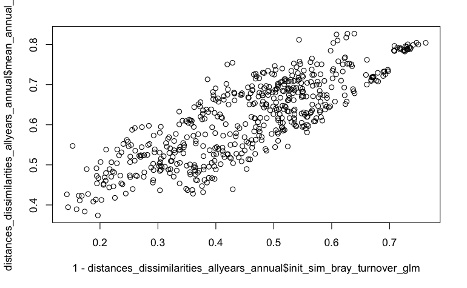

```r
plot(1-distances_dissimilarities_allyears_annual$init_sim_bray_turnover_glm, distances_dissimilarities_allyears_annual$mean_annual_bray)
```

```r
saveRDS(distances_dissimilarities_allyears_annual_decay, "/Users/zoekitchel/Documents/grad_school/Rutgers/Repositories/trawl_spatial_turnover_git/output/distance_decay/distances_dissimilarities_allyears_annual_decay.rds")
```

Plot halving distance, init similarity, mean and median bray across time

Wide to long for plotting

```r
#add initial dissimilarity
distances_dissimilarities_allyears_annual[,init_dissim_bray_turnover_glm := 1-init_sim_bray_turnover_glm][,init_dissim_jaccard_turnover_glm := 1-init_sim_jaccard_turnover_glm]

#wide to long for plotting
distances_dissimilarities_allyears_annual.l <- melt(distances_dissimilarities_allyears_annual, id.vars = c("season_survey","year","year_in_seq"), measure.vars = c(4:8,12,15:16), variable.name = "Div_Metric")
```

```r
(all_0_1_metrics_over_time <- ggplot(distances_dissimilarities_allyears_annual.l[value <= 1 & value >= 0]) +
  geom_point(aes(x = year, y = value, color = Div_Metric), size = 1) +
  facet_wrap(~season_survey, scales = "free") +
  theme_classic())

ggsave(all_0_1_metrics_over_time, filename = "all_0_1_metrics_over_time.jpg", path = "/Users/zoekitchel/Documents/grad_school/Rutgers/Repositories/trawl_spatial_turnover_git/figures/alternate_metrics", width = 15, height = 7, unit = "in")

#non 0_1 metrics over time
(all_halv_dist_over_time <- ggplot(distances_dissimilarities_allyears_annual.l[value > 1 | value < 0]) +
  geom_point(aes(x = year, y = value, color = Div_Metric), size = 1) +
  facet_wrap(~season_survey, scales = "free") +
  theme_classic())

ggsave(all_halv_dist_over_time, filename = "all_halv_dist_over_time.jpg", path = "/Users/zoekitchel/Documents/grad_school/Rutgers/Repositories/trawl_spatial_turnover_git/figures/alternate_metrics", width = 15, height = 7, unit = "in")
```

Q for next time: -in which regions do jaccard and bray results match vs. which regions do they not match -halving distance versus initial similarity

Janne Soininen,Robert McDonald,Helmut Hillebrand 2007

- The initial similarity reflects beta diversity (i.e. turnover in species composition from site to site) at small spatial extents, and high initial similarities mirror low beta diversity.
- The halving distance reflects the rate of species turnover per unit distance, being thus a measure of the scale-dependency of beta diversity. Large halving distances indicate that the rate of species turnover change little with increasing spatial scale, while short halving distances imply that species turnover is highly scale-dependent.
- The major advantage of the halving distance over any measure of slope is that it can be calculated for any type of regression between similarity and distance, and offers thus a highly useful and easily comprehensible metric for among-study comparisons. (this isn’t really important for us)

##What if we run model with means instead of every datapoint? Compare model summaries, and SD for slopes and intercepts of random effect of season_survey.

```r
library(mgcv) #to make gam

#what if we run model with means instead of every datapoint?
bray_curtis_dissimilarity_year_mod_annual_avg <- lmer(mean_annual_bray ~ year_in_seq + (1 + year_in_seq|season_survey),data = distances_dissimilarities_allyears_annual)

jaccard_dissimilarity_year_mod_annual_avg <- lmer(mean_annual_jaccard ~ year_in_seq + (1 + year_in_seq|season_survey),data = distances_dissimilarities_allyears_annual)

#what if we run model with median instead of every datapoint?

bray_curtis_dissimilarity_year_mod_annual_median <- lmer(median_annual_bray ~ year_in_seq + (1 + year_in_seq|season_survey),data = distances_dissimilarities_allyears_annual)

jaccard_dissimilarity_year_mod_annual_median <- lmer(median_annual_jaccard ~ year_in_seq + (1 + year_in_seq|season_survey),data = distances_dissimilarities_allyears_annual)

#and, we need to use year instead of year in seq (DOESN'T WORK: boundary (singular) fit: see ?isSingular)
bray_curtis_dissimilarity_year_mod_annual_avg_YEAR <- lmer(mean_annual_bray ~ year + (1 + year|season_survey), data = distances_dissimilarities_allyears_annual)


summary(bray_curtis_dissimilarity_year_mod_annual_avg)
summary(intercept_slope_varies)

#what about a gam, and use actual year instead of year in seq

bray_curtis_dissimilarity_year_mod_annual_avg_GAM <- gam(mean_annual_bray ~ year +
                                                           s(season_survey,year, bs = "fs", m = 1), #random smooth
                                                         data = distances_dissimilarities_allyears_annual)

jaccard_dissimilarity_year_mod_annual_avg_GAM <- gam(mean_annual_jaccard ~ year +
                                                           s(season_survey,year, bs = "fs", m = 1), #random smooth
                                                         data = distances_dissimilarities_allyears_annual)

summary(bray_curtis_dissimilarity_year_mod_annual_avg_GAM)
```

Plotting LMER with only one value per year region combo (mean values of dissimilarity per year)

```r
# see group coefficients
model_coefs_reduced <- coef(bray_curtis_dissimilarity_year_mod_annual_avg)$season_survey
model_coefs_reduced_YEAR <- coef(bray_curtis_dissimilarity_year_mod_annual_avg_YEAR)$season_survey
model_coefs_reduced_jaccard <- coef(jaccard_dissimilarity_year_mod_annual_avg)$season_survey

model_coefs_reduced$season_survey <- rownames(model_coefs_reduced)
model_coefs_reduced_YEAR$season_survey <- rownames(model_coefs_reduced_YEAR)
model_coefs_reduced_jaccard$season_survey <- rownames(model_coefs_reduced_jaccard)

model_coefs_reduced <- data.table(model_coefs_reduced)
model_coefs_reduced_YEAR <- data.table(model_coefs_reduced_YEAR)
model_coefs_reduced_jaccard <- data.table(model_coefs_reduced_jaccard)


#merge with duration of survey
model_coefs_reduced_length <- model_coefs_reduced[survey_season_sampling_years, on = "season_survey"]
model_coefs_reduced_jaccard <- model_coefs_reduced_jaccard[survey_season_sampling_years, on = "season_survey"]

model_coefs_reduced_length[,years_sampled := as.numeric(years_sampled)][,Directional_Change := ifelse(year_in_seq > 0, "Differentiation","Homogenization")]
model_coefs_reduced_jaccard[,years_sampled := as.numeric(years_sampled)][,Directional_Change := ifelse(year_in_seq > 0, "Differentiation","Homogenization")]

model_coefs_reduced_length_YEAR <- model_coefs_reduced_YEAR[survey_season_sampling_years, on = "season_survey"]

model_coefs_reduced_length_YEAR[,years_sampled := as.numeric(years_sampled)][,Directional_Change := ifelse(year > 0, "Differentiation","Homogenization")]

#min max distances_dissimilarities
min_bray_reduced <- min(distances_dissimilarities_allyears_annual[,mean_annual_bray], na.rm = T)
max_bray_reduced <- max(distances_dissimilarities_allyears_annual[,mean_annual_bray], na.rm = T)

#order table by coefficient
setorder(model_coefs_reduced_length, year_in_seq)
setorder(model_coefs_reduced_jaccard, year_in_seq)

#add colors
model_coefs_reduced_length <- model_coefs_reduced_length[color_link, on = "season_survey"]
model_coefs_reduced_jaccard <- model_coefs_reduced_jaccard[color_link, on = "season_survey"]


colors_ordered <- copy(unique(model_coefs_reduced_length[,hex]))
colors_ordered_jaccard <- copy(unique(model_coefs_reduced_jaccard[,hex]))


#BRAY
#year in seq
BC_Dissimilarity_Coef_errorbar_reduced <- ggplot(data = model_coefs_reduced_length, aes(x = reorder(season_survey, year_in_seq) , y = year_in_seq, label = season_survey)) +
    geom_errorbar(aes(ymin = year_in_seq - 0.002681, ymax = year_in_seq + 0.002681), color = "grey") + #add standard deviation
  geom_point(stat = 'identity', aes(size = years_sampled, color = Directional_Change)) +
  scale_size_binned(range = c(1,8), name = "Survey Period Length") +
  scale_color_discrete(name = "Directional Change") +
  geom_hline(yintercept = 0) +
  xlab("Season and Survey") +
  ylab("Coef BC Dissimilarity ~ Year") +
  coord_flip() +
  theme_classic() +
  theme(axis.text.y = element_text(colour = colors_ordered, face = "bold"), axis.title.y = element_blank())

BC_Dissimilarity_Coef_errorbar_reduced

#compare to when all points are used

#JACCARD
#year in seq
jaccard_Dissimilarity_Coef_errorbar_reduced <- ggplot(data = model_coefs_reduced_jaccard, aes(x = reorder(season_survey, year_in_seq) , y = year_in_seq, label = season_survey)) +
    geom_errorbar(aes(ymin = year_in_seq - 0.002656, ymax = year_in_seq + 0.002656), color = "grey") + #add standard deviation
  geom_point(stat = 'identity', aes(size = years_sampled, color = Directional_Change)) +
  scale_size_binned(range = c(1,8), name = "Survey Period Length") +
  scale_color_discrete(name = "Directional Change") +
  geom_hline(yintercept = 0) +
  xlab("Season and Survey") +
  ylab("Coef Jaccard Dissimilarity ~ Year") +
  coord_flip() +
  theme_classic() +
  theme(axis.text.y = element_text(colour = colors_ordered_jaccard, face = "bold"), axis.title.y = element_blank())

jaccard_Dissimilarity_Coef_errorbar_reduced

#compare to when all points are used


library(cowplot)
BC_Dissimilarity_Coef_errorbar_merge_compare <- plot_grid(BC_Dissimilarity_Coef_errorbar+ylim(-0.008,0.008)+theme(legend.position = "null"), BC_Dissimilarity_Coef_errorbar_reduced+ylim(-0.008,0.008)+theme(legend.position = "null"), get_legend(BC_Dissimilarity_Coef_errorbar + theme(legend.position = "bottom")),
          ncol = 1)


ggsave(BC_Dissimilarity_Coef_errorbar_merge_compare, height = 6, width = 4, unit = "in",  path = "~/homogenization_analyses", filename = "BC_Dissimilarity_Coef_errorbar_merge.png",)


#JUST YEAR (DOESN'T WORKKK)
BC_Dissimilarity_Coef_errorbar_reduced_YEAR <- ggplot(data = model_coefs_reduced_length_YEAR, aes(x = reorder(season_survey, year) , y = year, label = season_survey)) +
    geom_errorbar(aes(ymin = year - 0.0001921, ymax = year + 0.0001921), color = "grey") + #add standard deviation
  geom_point(stat = 'identity', aes(size = years_sampled, color = Directional_Change)) +
  scale_size_binned(range = c(1,8)) +
  geom_hline(yintercept = 0) +
  xlab("Season and Survey") +
  ylab("Coef BC Dissimilarity ~ Year") +
  coord_flip() +
  theme_classic()

BC_Dissimilarity_Coef_errorbar_reduced_YEAR
```

Dissimilarity versus time for mean annual dissimilarity as input instead of all pairwise comparisons, with points

```r
points_wavylines_bray_year_reduced <- ggplot() +
  geom_point(data = distances_dissimilarities_allyears_annual,
             aes(x = year,
                 y = mean_annual_bray,
                 color = season_survey), alpha = 0.5) +
    geom_smooth(data = distances_dissimilarities_allyears_annual,
             aes(x = year,
                 y = mean_annual_bray,
                 color = season_survey), method = "gam", se = F, size = 0.5) +
#  geom_abline(data = model_coefs_length,
#              aes(intercept = `(Intercept)`,
#                  slope = year_in_seq,
#                  colour = season_survey
#                  ),
#              size = 0.5
#              ) +
  geom_smooth(data = distances_dissimilarities_allyears_annual) +
    scale_color_manual(values =  c("#5A5156","#E4E1E3","#F6222E","#FE00FA",
  "#16FF32","#3283FE","#FEAF16","#B00068",
  "#1CFFCE","#90AD1C","#2ED9FF","#DEA0FD",
  "#AA0DFE","#F8A19F","#325A9B","#C4451C",
  "#1C8356","#85660D","#B10DA1","#FBE426",
  "#1CBE4F","#FA0087","#FC1CBF","#F7E1A0",
  "#C075A6","#782AB6","#AAF400","#BDCDFF",
  "#822E1C","#B5EFB5","#7ED7D1","#1C7F93",
  "#D85FF7","#683B79","#66B0FF","#3B00FB")) +
  theme_classic() +
  xlab("Year") +
  ylab("Pairwise Bray Curtis Dissimilarity")

points_wavylines_bray_year_reduced

ggsave(points_wavylines_bray_year_reduced, path = "~/homogenization_analyses", filename = "points_wavylines_bray_year_reduced.png", height = 8, width = 12, units = "in")

#what if we plot actual model

ggplot() +
  plot_smooths(
  model = bray_curtis_dissimilarity_year_mod_annual_avg_GAM,
  series = year,
  comparison = season_survey
)

#for plotting, get model as predictions
bray_curtis_dissimilarity_year_mod_annual_avg_GAM_predictions <- predict(bray_curtis_dissimilarity_year_mod_annual_avg_GAM, se.fit = TRUE)
jaccard_dissimilarity_year_mod_annual_avg_GAM_predictions <- predict(jaccard_dissimilarity_year_mod_annual_avg_GAM, se.fit = TRUE)

#predict average lmer
bray_curtis_dissimilarity_year_mod_annual_avg_lmer_predictions <- predict(bray_curtis_dissimilarity_year_mod_annual_avg, se.fit = TRUE)
jaccard_dissimilarity_year_mod_annual_avg_lmer_predictions <- predict(jaccard_dissimilarity_year_mod_annual_avg, se.fit = TRUE)

#add to full data table

distances_dissimilarities_allyears_annual[,preds_bray_curtis_dissim := bray_curtis_dissimilarity_year_mod_annual_avg_GAM_predictions$fit][,se_bray_curtis_dissim := bray_curtis_dissimilarity_year_mod_annual_avg_GAM_predictions$se.fit][,lmer_avg := fixef(bray_curtis_dissimilarity_year_mod_annual_avg)[[1]] + fixef(bray_curtis_dissimilarity_year_mod_annual_avg_YEAR)[[2]] * year_in_seq]

distances_dissimilarities_allyears_annual[,preds_jaccard_dissim := jaccard_dissimilarity_year_mod_annual_avg_GAM_predictions$fit][,se_jaccard_dissim := jaccard_dissimilarity_year_mod_annual_avg_GAM_predictions$se.fit][,lmer_avg := fixef(jaccard_dissimilarity_year_mod_annual_avg)[[1]] + fixef(jaccard_dissimilarity_year_mod_annual_avg)[[2]] * year_in_seq]

#now plot

points_wavylines_bray_year_reduced_gam_YEAR <- ggplot() +
  geom_point(data = distances_dissimilarities_allyears_annual,
             aes(x = year,
                 y = mean_annual_bray,
                 color = season_survey), alpha = 0.5, size = 1) +
    geom_line(data = distances_dissimilarities_allyears_annual,
             aes(x = year,
                 y = preds_bray_curtis_dissim,
                 color = season_survey)) +
  geom_ribbon(data = distances_dissimilarities_allyears_annual, aes(x = year, ymin=preds_bray_curtis_dissim-se_bray_curtis_dissim, ymax=preds_bray_curtis_dissim+se_bray_curtis_dissim, fill = season_survey), alpha=0.1) +
#  geom_abline(data = model_coefs_length,
#              aes(intercept = `(Intercept)`,
#                  slope = year_in_seq,
#                  colour = season_survey
#                  ),
#              size = 0.5
#              ) +
  geom_smooth(data = distances_dissimilarities_allyears_annual, aes(x = year, y = lmer_avg), color = "black", method = "lm") +
    scale_color_manual(values =  palette_28, name = "Survey & Season") +
  scale_fill_manual(values =  palette_28, guide = "none") +
  theme_classic() +
  xlab("Year") +
  ylab("Pairwise Bray Curtis Dissimilarity")

points_wavylines_bray_year_reduced_gam_YEAR

ggsave(points_wavylines_bray_year_reduced_gam_YEAR, path = "~/homogenization_analyses", filename = "points_lines_bray_year.png", height = 8, width = 12, units = "in")

#same, but jaccard
points_wavylines_jaccard_year_reduced_gam_YEAR <- ggplot() +
  geom_point(data = distances_dissimilarities_allyears_annual,
             aes(x = year,
                 y = mean_annual_jaccard,
                 color = season_survey), alpha = 0.5, size = 1) +
    geom_line(data = distances_dissimilarities_allyears_annual,
             aes(x = year,
                 y = preds_jaccard_dissim,
                 color = season_survey)) +
  geom_ribbon(data = distances_dissimilarities_allyears_annual, aes(x = year, ymin=preds_jaccard_dissim-se_jaccard_dissim, ymax=preds_jaccard_dissim+se_jaccard_dissim, fill = season_survey), alpha=0.1) +
#  geom_abline(data = model_coefs_length,
#              aes(intercept = `(Intercept)`,
#                  slope = year_in_seq,
#                  colour = season_survey
#                  ),
#              size = 0.5
#              ) +
  geom_smooth(data = distances_dissimilarities_allyears_annual, aes(x = year, y = lmer_avg), color = "black", method = "lm") +
    scale_color_manual(values =  palette_28, name = "Survey & Season") +
  scale_fill_manual(values =  palette_28, guide = "none") +
  theme_classic() +
  xlab("Year") +
  ylab("Pairwise Jaccard Dissimilarity")

points_wavylines_jaccard_year_reduced_gam_YEAR

ggsave(points_wavylines_jaccard_year_reduced_gam_YEAR, path = "~/homogenization_analyses", filename = "points_lines_jaccard_year.png", height = 8, width = 12, units = "in")
```

Merge BC versus Year plot with GAMS and Region vs. coefficient plot for LMERs

```r
BC_GAM_LMER_merge <- plot_grid(points_wavylines_bray_year_reduced_gam_YEAR + theme(legend.position = "none", plot.margin = margin(2,0,0,0, unit = "cm")), BC_Dissimilarity_Coef_errorbar_reduced + theme(legend.position = "none", plot.margin = margin(2,0,0,0, unit = "cm")), labels = c("","Survey &\nSeason  ",""), vjust = 1.5, hjust = 0)

BC_GAM_LMER_merge_legend <- plot_grid(BC_GAM_LMER_merge, get_legend(BC_Dissimilarity_Coef_errorbar_reduced), rel_widths = c(10,2))

ggsave(BC_GAM_LMER_merge_legend, path = "~/homogenization_analyses", filename = "BC_GAM_LMER_merge_legend.png", height = 7, width = 12, units = "in")
```

Merge Jaccard versus Year plot with GAMS and Region vs. coefficient plot for LMERs

```r
jaccard_GAM_LMER_merge <- plot_grid(points_wavylines_jaccard_year_reduced_gam_YEAR + theme(legend.position = "none", plot.margin = margin(2,0,0,0, unit = "cm")), jaccard_Dissimilarity_Coef_errorbar_reduced + theme(legend.position = "none", plot.margin = margin(2,0,0,0, unit = "cm")), labels = c("","Survey &\nSeason  ",""), vjust = 1.5, hjust = 0)

jaccard_GAM_LMER_merge_legend <- plot_grid(jaccard_GAM_LMER_merge, get_legend(jaccard_Dissimilarity_Coef_errorbar_reduced), rel_widths = c(10,2))

ggsave(jaccard_GAM_LMER_merge_legend, path = "~/homogenization_analyses", filename = "jaccard_GAM_LMER_merge_legend.png", height = 7, width = 12, units = "in")
```